# Codebook for df

## Address

| Feature | Result |
| --- | --- |
| Variable type | character |
| Number of missing obs. | 0 (0 %) |
| Number of unique values | 76 |
| Mode | “Jln Profesor Diraja Ungku Aziz, 50603 Kuala Lumpur, Wilayah Persekutuan Kuala Lumpur” |

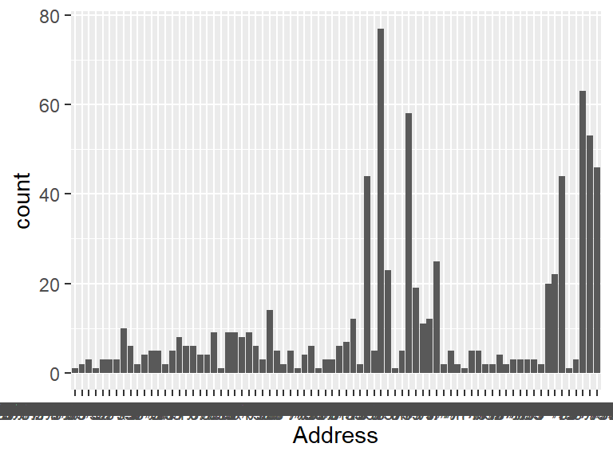

- Observed factor levels: "", " Faculty for Language Studies and Human Development, Universiti Malaysia Kelantan, 16300 Bachok, Kelantan.", "Akademi Seni dan Teknologi Kreatif\nUniversiti Malaysia Sabah\nJalan UMS, 88400\nKota Kinabalu\nSabah, Malaysia", "Department of Data Science Universiti Malaysia Kelantan UMK City Campus Pengkalan Chepa", "Faculty Bioengineering and Technology University Malaysia Kelantan, Jeli Campus, Jeli, Kelantan Malaysia.", "Faculty of Applied and Human Sciences\nUniversiti Malaysia Perlis (UniMAP)\nJalan Alor Setar-Kangar", "Faculty of Architecture and Ekistics, Universiti Malaysia Kelantan", "Faculty of Business, Economics and Accountancy,\nUniversiti Malaysia Sabah,\nJalan UMS, 88400, Kota Kinabalu, Sabah, Malaysia", "FACULTY OF BUSINESS, ECONOMICS AND SOCIAL DEVELOPMENT, University of Malaysia Terengganu, 21030 Kuala Nerus, Terengganu, Malaysia", "Faculty of Civil Engineering and Built Environment, Universiti Tun Hussein Onn Malaysia, 86400 Parit Raja, Batu Pahat, Johor, Malaysia", "Faculty of Civil Engineering Technology,\nUniversiti Malaysia Perlis (UniMAP), \nKompleks Pusat Pengajian Jejawi 3, 02600 Arau, Perlis, MALAYSIA.", "Faculty of Computer Science & Information Technology,\nUniversiti Tun Hussein Onn Malaysia,\n86400, Parit Raja, Batu Pahat, Johor, Malaysia.", "Faculty Of Computing and Informatics,? ? ? ? ? ? ? ? ? ? ? ? ? ? ? ? ? ? ? ? ? ? Universiti Malaysia Sabah, Sabah, Malaysia.", "Faculty of Electrical and Electronic Engineering (FKEE)\nUniversiti Tun Hussein Onn Malaysia (UTHM)\n86400 Parit Raja, Batu Pahat\nJohor, Malaysia", "Faculty of Electrical Engineering Technology\nUniversiti Malaysia Perlis\nPauh Putra Campus\n02600 Arau, Perlis", "Faculty of Electronic Engineering Technology (FTKEN)\nUniversiti Malaysia Perlis (UniMAP), \nPauh Putra Campus, 02600 Arau, Perlis, MALAYSIA.", "Faculty Of EngineeringUniversiti Malaysia SabahJalan UMS, 88400Kota Kinabalu, Sabah", "Faculty of Fisheries and Food Science, Universiti Malaysia Terengganu, 21030 Kuala Nerus, Terengganu, Malaysia", "FACULTY OF FOOD SCIENCE AND NUTRITION, UNIVERSITI MALAYSIA SABAH, JALAN UMS, 88400 KOTA KINABALU SABAH, MALAYSIA", "Faculty of Mechanical and Manufacturing Engineering, Universiti Tun Hussein Onn Malaysia, 86400 Parit Raja, Batu Pahat, Johor, Malaysia", "Faculty of Mechanical Engineering Technology,\nUniversiti Malaysia Perlis, Kampus Tetap Pauh Putra, 026000 Arau, Perlis, Malaysia", "Faculty of Medicine and Health Sciences UMS, ???????Jalan UMS, 88400, Kota Kinabalu, Sabah, Malaysia.", "Faculty of Ocean Engineering Technology and Informatics (FTKKI)\nUniversiti Malaysia Terengganu, 21030 Kuala Nerus, Terengganu, Malaysia", "Faculty of Psychology and Education, 88400 Kota Kinabalu, Sabah", "Faculty of Science and Marine Environment,\nUniversiti Malaysia Terengganu,\n21030 Kuala Nerus,\nTerengganu, MALAYSIA", "Faculty of Science and Natural Resources, Universiti Malaysia Sabah,88400 Kota Kinabalu,Sabah, MALAYSIA", "Faculty of Social Science and Humanities\n Universiti Malaysia Sabah\n Jalan UMS, 88400, Kota Kinabalu, Sabah, Malaysia", "Faculty of Sustainable Agriculture,? Universiti Malaysia Sabah, Locked Bag No. 3, 90509 Sandakan,Sabah, Malaysia.", "Faculty of Technical and Vocational Education\n\n Universiti Tun Hussein Onn Malaysia\n\n 86400 Parit Raja, Batu Pahat\n\n Johor, Malaysia", "Faculty of Technology and Business Management, Jalan FPTP,\nUniversiti Tun Hussein Onn Malaysia,\n86400 Parit Raja,\nBatu Pahat, Johor\nMalaysia", "Faculty of Technology Creative and Heritage University Malaysia Kelantan, UMK Bachok, Bachok, Kelantan Malaysia", "Faculty of Tropical Forestry, Universiti Malaysia Sabah. Kota Kinabalu, Sabah, Malaysia", "FACULTY OF VETERINARY MEDICINE, UNIVERSITI MALAYSIA KELANTAN, PENGKALAN CHEPA 16100 KOTA BHARU, KELANTAN", "Fakulti Industri Asas Tani, Universiti Malaysia Kelantan, Kampus Jeli, 17600 Jeli, Kelantan.", "Fakulti Keusahawanan dan Perniagaan, Kampus Kota, Pengkalan Chepa, 16100 Kota Bharu, Kelantan.", "Fakulti Pengajian Islam ( FIS )\n\nBlok A, Aras 4 Bangunan FKJ ( Pejabat Sementara )\n\nUniversiti Malaysia Sabah, Jalan UMS\n\n88400 Kota Kinabalu, Sabah", "Fakulti Pengajian Maritim, Universiti Malaysia Terengganu, 21030 Kuala Terengganu, Terengganu.", "FAKULTI SAINS BUMI, UNIVERSITI MALAYSIA KELANTAN KAMPUS JELI\n", "Fakulti Sains Gunaan dan Teknologi, UTHM Kampus Pagoh, KM1, Jln Panchor, 84600 Muar, Johor", "Fakulti Teknologi Kejuruteraan Kimia (FTKK)\nKompleks Pusat Pengajian Jejawi 3\nKawasan Perindustrian Jejawi \nUniversiti Malaysia Perlis (UniMAP)\n02600 Arau, Perlis , Malaysia", "Fakulti Teknologi Kejuruteraan\nUniversiti Tun Hussein Onn Malaysia, Pagoh Higher Education Hub, 84600 Pagoh, Muar, Johor.", "Islamic Business SchoolCollege of Business,Universiti Utara Malaysia,06010 UUM Sintok,?Kedah Darul Aman, MALAYSIA.", "Jalan Hang Tuah Jaya, 76100 Durian Tunggal, Melaka", "Jalan Sultan Yahya Petra, Kampung Datuk Keramat, 54100 Kuala Lumpur, Wilayah Persekutuan Kuala Lumpur", "Jln Profesor Diraja Ungku Aziz, 50603 Kuala Lumpur, Wilayah Persekutuan Kuala Lumpur", "Kem, Sungai Besi, 57000 Kuala Lumpur", "Level 2, Kompleks Pendidikan Perubatan Canselor Tuanku Ja?afar, Jalan Yaacob Latif, Bandar Tun Razak, 56000 Cheras, Kuala Lumpur, Malaysia.", "Level 3, Universiti Malaysia Sabah, Labuan International Campus, Jalan Sungai Pagar, 87000 Federal Territory of Labuan.", "Pusat Kembangan PendidikanAras 2, Bangunan WawasanUniversiti Kebangsaan Malaysia43600 UKM Bangi Selangor", "Pusat Pengajian Ilmu Pendidikan, Universiti Sains Malaysia,11800 USM, Pulau Pinang Malaysia", "Pusat Pengajian Kejuruteraan Elektrik Dan Elektronik, USM, kampus Kejuruteraan, Seberang Perai Selatan, Nibong Tebal, Penang 14300 Malaysia", "Pusat Pengajian Sains Pergigian, Kampus Kesihatan, Universiti Sains Malaysia, 16150 Kubang Kerian, Kelantan, Malaysia.", "Pusat Pengajian Teknologi Industri, Universiti Sains Malaysia 11800 Penang.", "School of Applied Psychology, Social Work and PolicyUUM College of Arts & Sciences,Universiti Utara Malaysia,06010 UUM Sintok,Kedah Darul Aman, MALAYSIA.", "School of Business ManagementCollege of Business,Universiti Utara Malaysia,06010 UUM Sintok,?Kedah Darul Aman, MALAYSIA.", "School of ComputingUUM College Arts & Sciences,Universiti Utara Malaysia,06010 UUM Sintok,?Kedah Darul Aman, MALAYSIA.", "School of Creative Industry Management & Performing ArtsCollege of Arts & Sciences,Universiti Utara Malaysia,06010 UUM Sintok,Kedah Darul Aman,?MALAYSIA.?", "School of Economics, Finance & BankingCollege of Business,Universiti Utara Malaysia,06010 UUM Sintok,?Kedah Darul Aman, MALAYSIA.?", "School of EducationUniversiti Utara Malaysia,06010 UUM Sintok,?Kedah Darul Aman, MALAYSIA.", "School of GovernmentCollege of Law, Government & International Studies,Universiti Utara Malaysia,06010 UUM Sintok,Kedah Darul Aman,?MALAYSIA.?", "School of International StudiesCollege of Law, Government & International Studies,Universiti Utara Malaysia,06010 UUM Sintok,Kedah Darul Aman,?MALAYSIA.?", "School of Languages, Civilisation & PhilosophyUniversiti Utara Malaysia,06010 UUM Sintok,Kedah Darul Aman,?MALAYSIA.?", "School of LawCollege of Law, Government & International Studies,Universiti Utara Malaysia,06010 UUM Sintok,Kedah Darul Aman,?MALAYSIA.?", "School of Multimedia Technology & CommunicationCollege of Arts & Sciences,Universiti Utara Malaysia,06010 UUM Sintok,Kedah Darul Aman,?MALAYSIA.?", "School of Quantitative SciencesCollege of Arts & Sciences,Universiti Utara Malaysia,06010 UUM Sintok,Kedah Darul Aman,?MALAYSIA.?", "School of Technology Management & LogisticsCollege of Business,Universiti Utara Malaysia,06010 UUM Sintok,?Kedah Darul Aman, MALAYSIA.", "School of Tourism, Hospitality & Event ManagementCollege of Law, Government & International Studies,Universiti Utara Malaysia,06010 UUM Sintok,Kedah Darul Aman,?MALAYSIA.?", "Tunku Puteri Intan Safinaz School of AccountancyCollege of Business,Universiti Utara Malaysia,06010 UUM Sintok,?Kedah Darul Aman,?MALAYSIA.?", "UMP Gambang Campus", "UMP Pekan Campus", "UNIMAS Holdings Sdn. Bhd, Level 6, UNIMAS City Campus, Lot 77, Section 22,KTLD Jalan Tun Ahmad Zaidi Adruce, 93150 Kuching,Sarawak, Malaysia", "Universiti Kebangsaan Malaysia, Jalan Raja Muda Abdul Aziz, 50300 Kuala Lumpur, Federal Territory of Kuala Lumpur", "Universiti Malaysia Kelantan, City Campus, Pengkalan Chepa", "Universiti Sultan Zainal Abidin, Kampung Gong Badak, 21300, Terengganu", "UNIVERSITI TEKNOLOGI MALAYSIA, 81310 Skudai, Johor Bahru, Johor, Malaysia.", "Upsi, 35900 Tanjong Malim, Perak".

## Contact

| Feature | Result |
| --- | --- |
| Variable type | character |
| Number of missing obs. | 0 (0 %) |
| Number of unique values | 110 |
| Mode | “Phone Number: +604-653 3888” |

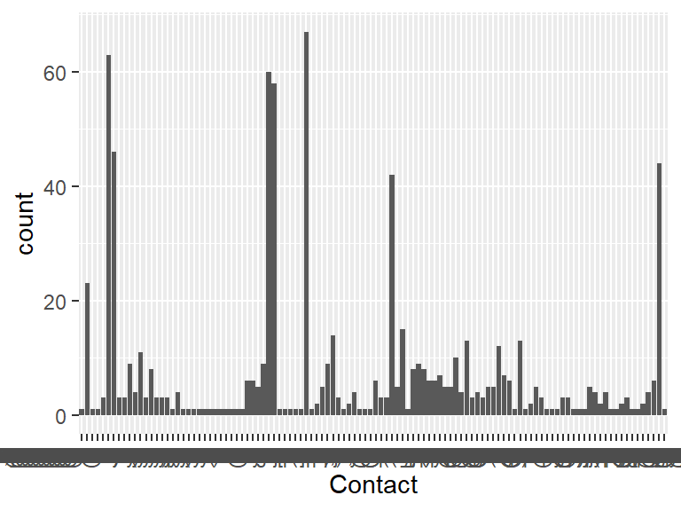

- Observed factor levels: "-", " 603-9051 3400", " Tel : +0088-320000 ext : 100658 , Fax : +6088 - 320268\n\nE-mail : pejfis@ums.edu.my", "(60) 88 320 000", "(60) 89 634 000 Fax : (60) 89 634 111", "+609 - 668 8793/7962/7968/8934\n", "015-48797982", "06-270 2112", "06-270 2571 ", "06-270 4018", "06-270 8002", "06-2701184", "06-2704341", "06 270 2411", "06 2702271", "6088-320000? ? ? ? ? ? ? ? ? ? ? ??", "609-6683791 / 609-668 4216 Fax : 609-668 4737 fpm@umt.edu.my", "Assoc. Prof. Dr. David Yeoh Eng Chuan\n\nPhone: +607-4564224 / +6013-6251500\n\nE-mail: david@uthm.edu.my", "Contact No: (+06) 088 - 320000 ext: 210 900 (General Office); 210 902 (Secretary Office)", "email: e-ftk@uthm.edu.my\nPhone: 06-974 2032 / 2140 / 2027", "email: e-ftk@uthm.edu.my\nPhone: 06-974 2032 / 2140 / 2028", "email: e-ftk@uthm.edu.my\nPhone: 06-974 2032 / 2140 / 2029", "email: e-ftk@uthm.edu.my\nPhone: 06-974 2032 / 2140 / 2030", "email: e-ftk@uthm.edu.my\nPhone: 06-974 2032 / 2140 / 2031", "email: e-ftk@uthm.edu.my\nPhone: 06-974 2032 / 2140 / 2032", "email: e-ftk@uthm.edu.my\nPhone: 06-974 2032 / 2140 / 2033", "email: e-ftk@uthm.edu.my\nPhone: 06-974 2032 / 2140 / 2034", "email: e-ftk@uthm.edu.my\nPhone: 06-974 2032 / 2140 / 2035", "email: e-ftk@uthm.edu.my\nPhone: 06-974 2032 / 2140 / 2036", "email: e-ftk@uthm.edu.my\nPhone: 06-974 2032 / 2140 / 2037", "email: e-ftk@uthm.edu.my\nPhone: 06-974 2032 / 2140 / 2038", "email: fast@uthm.edu.my", "Faculty Of EngineeringTel:088-320000 ext:3991 Fax:088-320348\\nEmail 1: fkj[at]ums.edu.my? ? ? ? ? ?Email 2: bahagianpentadbiranfkj[at]ums.edu.my", "fkalgo[at]ums.edu.my\n +6 087 503 000 (ext. 410 000)\n +6 087 503 113", "ftkki@umt.edu.my +609-6683555/+609-6683367", "LinkedIn: https://www.linkedin.com/company/studyukm/  
  Whatsapp: https://wa.me/601156354377\“, "Phone : +6 03-2615 4100  
  Email : corporate.kl@utm.my  
  https://kl.utm.my/\”, "Phone : 07-453 3841/3842/3839\nFax : 07 -453 3833", "Phone : 07-453 3841/3842/3839\nFax : 07 -453 3834", "Phone : 07-453 3841/3842/3839\nFax : 07 -453 3835", "Phone : 07-453 3841/3842/3839\nFax : 07 -453 3836", "Phone : 07-453 3841/3842/3839\nFax : 07 -453 3837", "Phone Number: +604-653 3888", "Phone: +609-771 7177  
  \n\nemail: jsd@umk.edu.my", "Phone: +6097797260  
  \n\n email: ftkw@umk.edu.my", "Phone: +604-9885601  
  \nFax: +604-9885606", "Phone: +604 988 5035  
  \nEmail: pa_ftkm@unimap.edu.my", "Phone: +607-4564115/4113/4030/4028\n\nFax: +607-4536585\n\nemail: fptv@uthm.edu.my", "Phone: +609-7717157  
  \n\n email: fhpk@umk.edu.my", "Phone: +609-7717279  
  \n\n Email: fpv@umk.edu.my", "Phone: +609-779 7445  
  \nemail: fbi@umk.edu.my", "Phone: +609-9477020 / 09-9477441  
  \n email: fiat@umk.edu.my", "Phone: +609-9477341", "Phone: +609-9477342", "Phone: +609-9477343", "Phone: +6097717127  
  \n\n email: prasiswazah.fkp@umk.edu.my", "Phone: +6097797560  
  \n\n email: fae@umk.edu.my", "Phone: +6099477406  
  \n email: fbkt@umk.edu.my", "Phone: 09 424 5000", "Phone:\n+6088-320000 Ext.: 210200 Fax: +088-320876\nEmail:\npejfpt@ums.edu.my", "Tel : 04 - 988 5509/5515  
  Fax : 04 - 988 5510  
  Email : ftken@unimap.edu.my", "Tel : +6088 - 320000, Ext : 100658Fax : +6088 - 320101ADMINISTRATION OFFICE BLOCK OF EDUCATIONTel : +6088 - 320000, Ext : 100658Fax : +6088 - 320268 ", "Tel : +6088 - 320000, Ext : 100658Fax : +6088 - 320268", "Tel : +6088 320000 Ext 5872Fax: +6088 435425?Email: pejfssa[at]ums.edu.my?", "Tel : +609 668 3615 / 3990Fax : +609 668 3193", "Tel : +609 668 4930 / 4931 Fax : +609 668 4949 Email: fpsm@umt.edu.my", "Tel : +609 6684149 Fax : +609 6684237 Email: fbesd@umt.edu.my", "Tel : 04 - 9798751  
  Fax : 04 - 9798755  
  \nEmail : dekanftkk@unimap.edu.my", "Tel :087-503000 Ext: 410300 (Labuan),??????????????????????????????????????????? 088-320000 Ext: 210600 (Kota Kinabalu)? ? ? ? ????? ? ? ? ?? ? ? ? ???????????? Fax :087-503114? ? ? ?? ? ? ? ? ? ? ? ? ? ?? Email: pejfki[at]ums.edu.my", "Tel.: +(607) 453 3601\nFax: +(607) 453 6023\nemail: azizulr@uthm.edu.my", "Tel: (+6088) 320000 \nExt.: 1413 / 1520 / 1519\nFax: (+6088) 320360\nEmail: pejfpep@ums.edu.my", "Tel: +603-7949 2050  
  Fax: +603-7954 0533  
  Email: fomadmin@um.edu.my", "Tel: +603-7967 3177  
  Fax: +603-7957 9707  
  Email: dekan_fbl@um.edu.my", "Tel: +603-7967 3454  
  Fax: +603-7967 3576  
  Email: creativearts@um.edu.my", "Tel: +603-7967 3800  
  Fax: +603-7967 3980  
  Email: umfba@um.edu.my", "Tel: +603-7967 5000 / 5133  
  Fax: +603-7956 5506  
  Email : dekan_pendidikan@um.edu.my", "Tel: +603-7967 5200 / 5201 / 5202  
  Fax: +603-7955 5781  
  Email: engine@um.edu.my", "Tel: +603-7967 5395  
  Fax: +603-7967 5713  
  Email: fab@um.edu.my", "Tel: +603-7967 5500  
  Fax: +603-7967 5707  
  Email: sastera@um.edu.my", "Tel: +603-7967 6000  
  Fax: +603-7956 0705  
  Email: aka_islam@um.edu.my", "Tel: +603-7967 6300  
  Fax: +603-7957 9249  
  Email: dekan_fsktm@um.edu.my", "Tel: +603-7967 6500/ 6501  
  Fax: +603-7957 3239  
  Email: law@um.edu.my", "Tel: +603 - 7967 4200  
  Fax: +603- 7956 6343  
  Email : science@um.edu.my", "Tel: +603 -7967 4800  
  Fax: +603 -7967 4809  
  Email: dekan_dental@um.edu.my", "Tel: +604-928 5001Fax: +604-928 5067", "Tel: +604-928 5381 Fax: +604-928 5382", "Tel: +604-928 5701/5881Fax: +604-928 5709", "Tel: +604-928 5701/5881Fax: +604-928 5709 ", "Tel: +604-928 5717/5718/5719/5720Fax: +604-928 5757", "Tel: +604-928 5717/5718/5719/5720Fax: +604-928 5757 ", "Tel: +604-928 5800/5801/5802/5803Fax: +604-928 5804", "Tel: +604-928 6301Fax: +604-928 6309", "Tel: +604-928 6453Fax: +604-928 5804", "Tel: +604-928 6651/6658/6655Fax: +604-928 6653", "Tel: +604-928 6651/6658/6655Fax: +604-928 6653 ", "Tel: +604-928 6751/6758/6763/6766Fax: +604-928 6752", "Tel: +604-928 7001Fax: +604-928 7070", "Tel: +604-928 7204 / 7217 (Postgraduate)Tel:?+604-928 7206 / 7209 (Undergraduate)Tel: +604-928 7201 (General Line)Fax: +604-928 7215", "Tel: +604-928 7401Fax: +604-928 7422", "Tel: +604-928 7401Fax: +604-928 7422 ", "Tel: +604-928 7901/7906Fax: +604-928 7914 ", "Tel: +604-928 8101Fax: +604-928 8107", "Tel: +604-928 8158/8159/8160/8161/8162Fax: +604-928 8163", "Tel: +604-928 8451Fax: +604-928 8470", "Tel: +604-928 8451Fax: +604-928 8470 ", "Tel: +607-4564505\nFax: +607-453 6337\nEmail: dekan.fkee@uthm.edu.my", "Tel: +6074537703 Fax: +6074536080 ", "Tel:(+6088)320 000 Ext : 1771/2710/2711 \nEmail : pejfssk@ums.edu.my", "Telephone: +60 82 22 2000 Fax: +60 82 22 2107 Email: helpdesk@unimasholdings.com", "Ts. Dr. Izudinshah Abd Wahab\n\nPhone: +607-4564227 / +6012-4401206\n\nE-mail: izudin@uthm.edu.my".

## Duration

| Feature | Result |
| --- | --- |
| Variable type | integer |
| Number of missing obs. | 132 (16.84 %) |
| Number of unique values | 5 |
| Median | 4 |
| 1st and 3rd quartiles | 4; 4 |
| Min. and max. | 2; 6 |

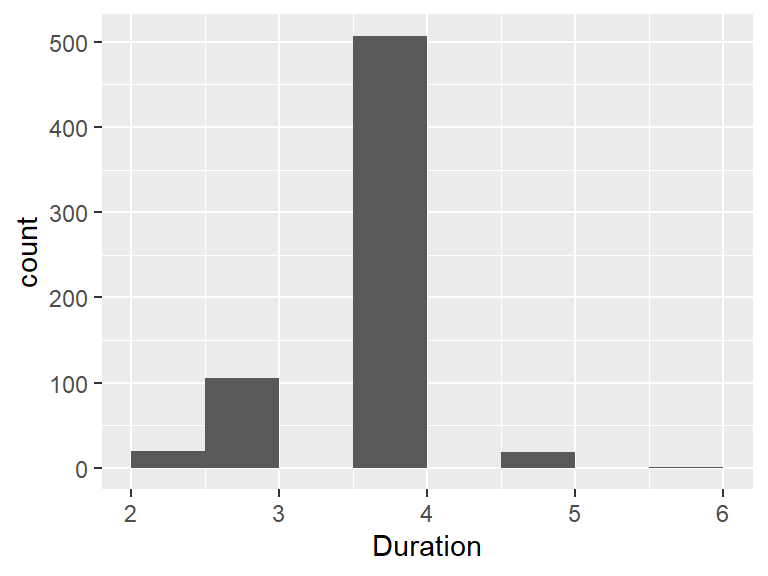

## Fee

| Feature | Result |
| --- | --- |
| Variable type | integer |
| Number of missing obs. | 134 (17.09 %) |
| Number of unique values | 117 |
| Median | 11200 |
| 1st and 3rd quartiles | 9200; 13626 |
| Min. and max. | 1419; 4e+05 |

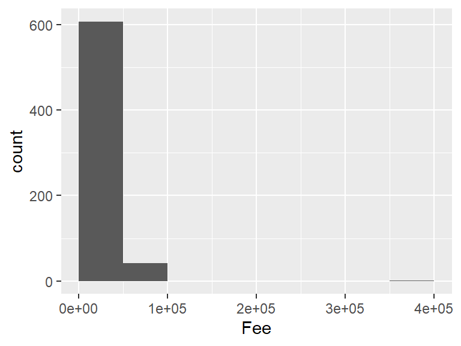

## uni_name

| Feature | Result |
| --- | --- |
| Variable type | character |
| Number of missing obs. | 0 (0 %) |
| Number of unique values | 16 |
| Mode | “Universiti Malaya (UM)” |

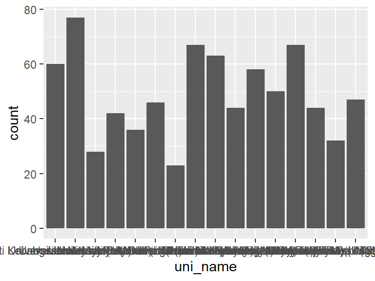

- Observed factor levels: "Universiti Kebangsaan Malaysia (UKM)", "Universiti Malaya (UM)", "Universiti Malaysia Kelantan (UMK)", "Universiti Malaysia Pahang(UMP)", "Universiti Malaysia Perlis (UniMAP)", "Universiti Pendidikan Sultan Idris (UPSI)", "Universiti Pertahanan Nasional Malaysia (UPNM)", "Universiti Sains Malaysia(USM)", "Universiti Sultan Zainal Abidin (UNISZA)", "Universiti Teknikal Malaysia Melaka (UTeM)", "Universiti Teknologi Malaysia (UTM)", "Universiti Tun Hussein Onn Malaysia (UTHM)", "Univesity Malaysia Sabah (UMS)", "Univesity Malaysia Sarawak (UNIMAS)", "Univesity Malaysia Terengganu (UMT)", "Univesity Utara Malaysia (UUM)".

## Fac_link

| Feature | Result |
| --- | --- |
| Variable type | character |
| Number of missing obs. | 0 (0 %) |
| Number of unique values | 15 |
| Mode | “” |

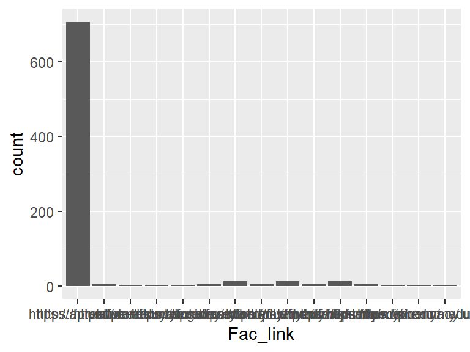

- Observed factor levels: "", "https://apium.um.edu.my/\“, "https://creativearts.um.edu.my/\”, "https://dentistry.um.edu.my/\“, "https://education.um.edu.my/\”, "https://engine.um.edu.my/\“, "https://fass.um.edu.my/\”, "https://fbe.um.edu.my/\“, "https://fll.um.edu.my/\”, "https://fpe.um.edu.my/\“, "https://fs.um.edu.my/\”, "https://fsktm.um.edu.my/\“, "https://law.um.edu.my/\”, "https://medicine.um.edu.my/ug\“, "https://pharmacy.um.edu.my/\”.

Report generation information:

- Created by: zianttt (username: `ziant`).
- Report creation time: Sun Jan 23 2022 23:33:08
- Report was run from directory: `C:/Users/ziant/Desktop/coding1/R/WIA1007_02`
- dataMaid v1.4.1 [Pkg: 2021-10-08 from CRAN (R 4.1.2)]
- R version 4.1.1 (2021-08-10).
- Platform: x86_64-w64-mingw32/x64 (64-bit)(Windows 10 x64 (build 19042)).
- Function call: `dataMaid::makeDataReport(data = df, mode = c("summarize", "visualize", "check"), smartNum = FALSE, file = "codebook_df.Rmd", checks = list( character = "showAllFactorLevels", factor = "showAllFactorLevels", labelled = "showAllFactorLevels", haven_labelled = "showAllFactorLevels", numeric = NULL, integer = NULL, logical = NULL, Date = NULL), listChecks = FALSE, maxProbVals = Inf, codebook = TRUE, reportTitle = "Codebook for df")`